# Concepts de probabilités

Probabilités et statistique pour la biologie (STAT1)

Jacques van Helden

2018-11-09

# Définitions de la probabilité

## Définition fréquentielle de la probabilité

Lors d’une expérience aléatoire, la *probabilité* d’un événement $A$ est la limite de sa fréqunce de réalisation quand le nombre d’essais tend vers l’infini.

$$\operatorname{P}(A) = \lim_{n \to \infty}\frac{n_{A}}{n}$$

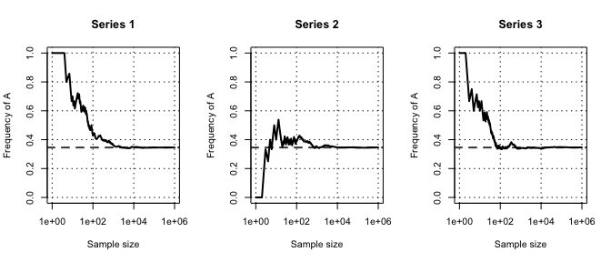

Fréquences de A lors du tirage (avec remise) de positions aléatoires dans le génome de *Mycoplasma genitalium*.

## Probabilités pour des ensemble finins

Supposons qu’on tire des éléments dans un ensemble fini, en considérant certains tirages comme des succès ($A$). Dans cette situation, la probabilté est définie comme le rapport entre le nombre de tirages pouvant être considérés comme des succès ($n_A$) et le nombre total de tirages possibles ($n$).

$$\operatorname{P}(A) = \frac{n_A}{n}$$

**Exemple:** sélection aléatoire de 4 cartes dans un jeu de 52 cartes. Quelle est la probabilité d’avoir un carré (4 cartes identiques) ?

Le jeu de carte comporte 13 valeurs (As, 2, 3, …, Dame, Roi), il y a donc 13 possibilités d’obtenir un carré: $n_A = 13$.

Le nombre total de tirages de 4 cartes parmi 52 est fourni par le coefficient binomial:
$$n = \binom{52}{4} = 270725$$

$$\operatorname{P}(A) = \frac{n_A}{n} = \frac{13}{\binom{52}{4}} = \frac{13}{270725} = 4.8\times 10^{-5}$$

## Exercice: tirage de tétranucléotides dans un génome

On tire aléatoirement une position génomique. Quelle est la probabilité pour que le tétranucléotide commençant à cette position corresponde aux critères suivants ?

1. Etre composé uniquement de $A$.
2. Etre composé de 4 résidus distincts.
3. Ne comporter aucun $A$.

Formulez explicitement le raisonnement qui vous amène à la formule de calcul. Indiquez ensuite la formule générale (avec des symboles), puis la formule particulière avec les valeurs numériques. Il n’est pas nécessaire de calculer le résultat final.

# Probabilités d’événements combinés

## Exclusion mutuelle

On désigne des événements de **mutuellement exclusifs** quand la réalisation de l’un rend impossible la réalisation des autres. Leur **probabilité jointe** ($A_1$ et $A_2$) est donc nulle.

$$A_1,A_2 \text{mutuellement exclusifs} \iff \operatorname{P}(A_1 \land A_2) = 0$$

Le symbole $\land$ correspond au *et* logique.

Si deux événements $A_1$ et $A_2$ sont mutuellement exclusifs, la probabilité de réalisation de l’un ou de l’autre est la somme de leurs probabilités.

$$\operatorname{P}(A_1 \land A_2) = 0 \iff \operatorname{P}(A_1 \lor A_2) = \operatorname{P}(A_1) + \operatorname{P}(A_2)$$

## Complémentarité

Un ensemble d’événements ${A_1, A_2, \ldots, A_m}$ sont dit **complémentaires** s’ils sont mutuellement exclusifs et exhaustifs (il n’existe pas d’événement possible en dehors de l’ensemble).

La **probabilité de l’union** d’événements complémentaires vaut 1.

$$A_1, A_2, \ldots A_m \text{complementary} \Rightarrow \operatorname{P}(A_1 \lor A_2 \lor \ldots \lor A_m) = \operatorname{P}(A_1) + \operatorname{P}(A_1) + \ldots + \operatorname{P}(A_m) = 1$$

## Indépendance stochastique

Deux événements sont **stochastiquement indépendants** si la réalisation de l’un n’affecte pas la probabilité de réalisation de l’autre.

La **probabilité jointe** d’une série d’événements indépendants est le produit de leurs probabilités.

$$A_1, A_2, \ldots A_m \text{ independent } \nonumber\\
\Rightarrow \operatorname{P}(A_1 \land A_2 \land \ldots \land A_m) = \operatorname{P}(A_1) \operatorname{P}(A_2) \ldots \operatorname{P}(A_m)$$

## Formule générale de probabilités combinées

$$\operatorname{P}(A \lor B) = \operatorname{P}(A) + \operatorname{P}(B) - \operatorname{P}(A \land B)$$

## Schéma de Bernoulli

Un *essai de Bernoulli* est une expérience aléatoire qui peut résulter en deux événements possibles, dénommés *succès* et *échec*, chacun étant associé à une probabilité.

Un *schéma de Bernoulli* est une série d’essais qui satisfont les conditions suivantes:

1. Indépendance: le résultat d’un essai n’affecte pas les probabilités de succès de l’essai suivant.
2. La probabilité de succès est identique pour chacun des essais.

## Schéma de Bernoulli généralisé

On peut généraliser la définition précédente en considérant une série d’essais pouvant résulter en un nombre finis de résultats possibles, associés chacun à une probabilité. Si les essais successifs sont indépendants et les probabilités des événements constantes au fil des essais, on parle de *schéma de Bernoulli généralisé*.

**Exemple:** modèle de probabilité des nuclétides dans le génome de la levure, basé sur les fréquences nucléotidiques.

| Résidu | Occurrences génomiques | Fréquence génomique |
| --- | --- | --- |
| A | 3766191 | 0.3098064564636 |
| C | 2320522 | 0.1908858838986 |
| G | 2316991 | 0.1905954242278 |
| T | 3752889 | 0.3087122354100 |

Dans le cadre d’un tirage aléatoire, on va considèrer que chaque résidu a une probabilité particulière: $\operatorname{P}(A) = 0.31$, $\operatorname{P}(C) = 0.19$, $\operatorname{P}(G) = 0.19$, $\operatorname{P}(T) = 0.31$.

## Les modèles de Bernoulli conviennent-il pour les séquences biologiques ?

Le schéma de Bernoulli présente un intérêt évident: sa facilité d’utilisation. Cependant il n’est pas très approprié pour modéliser les successions de résidus dans les séquences macromoléculaires, pour plusieurs raisons.

- Dans les génomes, les fréquences de nucléoides varient en fonction du contexte (codant, non-codant, …).
- Dans les séquences codantes, dépendance entre les résidus d’un même codon, notamment au niveau de la dégénérescence du 3ème résidu.
- Dans les régions non-codantes, les oligonucléotides poly-A et poly-T sont plus fréquents (propriété agrégative).
- Dans les séquences protéines, les contraintes structurelles ont favorisé (par sélection) certaines successions d’acides aminés et défavorisé d’autres.

Les *modèles de Markov* permettent une modélisation plus fine des séquences biologiques, en exprimant la dépendance entre résidus voisins.

## Exercices

1. On tire un nucléotide au hasard dans le génome de la levure (probabilités a priori définies ci-dessus). Quelle est la probabilité de tirer une purine ($A$ ou $G$) ?
2. En supposant qu’une séquence est composée de résidus équiprobables, quelle est la probabilité du motif $GATWNA$ ($W$ signifie “$T$ ou $A$”, et $N$ correspond à n’importe quel nucléotide) ?
3. Même question en supposant les probabilités distinctes pour les nucléotides: $\operatorname{P}(A) = \operatorname{P}(T) = 0.3$, $\operatorname{P}(C) = \operatorname{P}(G)$ (à vous de calculer ces dernières).
4. En supposant des nucléotides équiprobables, quelle est la probabilités de n’observer aucun $A$ dans un oligonucléotide de taille 12 ?